# mini project 4(country )

# Analysis of the clusters

calculating the mean of all the variables of each clusters.¶

```python
Cluster_GDPP=pd.DataFrame(dat6.groupby(["cluster"]).gdpp.mean())
Cluster_child_mort=pd.DataFrame(dat6.groupby(["cluster"]).child_mort.mean())
Cluster_exports=pd.DataFrame(dat6.groupby(["cluster"]).exports.mean())
Cluster_income=pd.DataFrame(dat6.groupby(["cluster"]).income.mean())

Cluster_health=pd.DataFrame(dat6.groupby(["cluster"]).health.mean())
Cluster_imports=pd.DataFrame(dat6.groupby(["cluster"]).imports.mean())
Cluster_inflation=pd.DataFrame(dat6.groupby(["cluster"]).inflation.mean())
Cluster_life_expec=pd.DataFrame(dat6.groupby(["cluster"]).life_expec.mean())
Cluster_total_fer=pd.DataFrame(dat6.groupby(["cluster"]).total_fer.mean())
```

Concatenating all the grouped by data to create a new dataframe to find required mean.

```python
df = pd.concat([Cluster_GDPP,Cluster_child_mort,Cluster_income,Cluster_exports,Cluster_health,
                Cluster_imports,Cluster_inflation,Cluster_life_expec,Cluster_total_fer], axis=1)
```

```python
df.columns = ["GDPP","child_mort","income","exports","health","imports","inflation","life_expec","total_fer"]
df
```

| cluster | GDPP | child_mort | income | exports | health | imports | inflation | life_expec | total_fer |
| --- | --- | --- | --- | --- | --- | --- | --- | --- | --- |
| 0 | 1695.913043 | 93.284783 | 3516.804348 | 29.287174 | 6.338478 | 43.297826 | 12.097065 | 59.393478 | 5.090217 |
| 1 | 6719.790698 | 22.425581 | 12770.813953 | 40.382430 | 6.215581 | 46.932162 | 7.609023 | 72.582558 | 2.293256 |
| 2 | 43117.142857 | 4.897143 | 45802.857143 | 58.431429 | 8.917429 | 51.508571 | 2.535000 | 80.245714 | 1.741143 |

```python
df
```

| cluster | GDPP | child_mort | income | exports | health | imports | inflation | life_expec | total_fer |
| --- | --- | --- | --- | --- | --- | --- | --- | --- | --- |
| 0 | 1695.913043 | 93.284783 | 3516.804348 | 29.287174 | 6.338478 | 43.297826 | 12.097065 | 59.393478 | 5.090217 |
| 1 | 6719.790698 | 22.425581 | 12770.813953 | 40.382430 | 6.215581 | 46.932162 | 7.609023 | 72.582558 | 2.293256 |
| 2 | 43117.142857 | 4.897143 | 45802.857143 | 58.431429 | 8.917429 | 51.508571 | 2.535000 | 80.245714 | 1.741143 |

Analysing the clusters by comparing how the [gdpp, child_mort and income] vary for each cluster of countries to recognise and differentiate the clusters of developed countries from the clusters of under-developed countries. From above dataframe of means, we got the mean data of under-developed countries. So, creating a dataframe on the basis of same

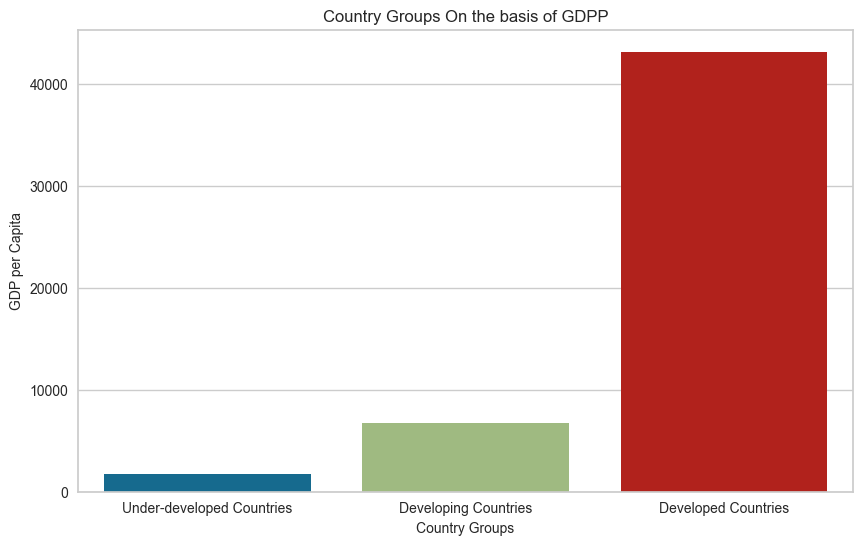

```python
fig = plt.figure(figsize = (10,6))
df.rename(index={0: 'Under-developed Countries'},inplace=True)
df.rename(index={1: 'Developing Countries'},inplace=True)
df.rename(index={2: 'Developed Countries'},inplace=True)
s=sns.barplot(x=df.index,y='GDPP',data=df)
plt.xlabel('Country Groups', fontsize=10)
plt.ylabel('GDP per Capita', fontsize=10)
plt.title('Country Groups On the basis of GDPP')
plt.show()
```

Above bar chart shows that, all the developed countries are having high GDP per capita values, developing countries are having average GDP per capita values and poor countries are having the least GDPP values.

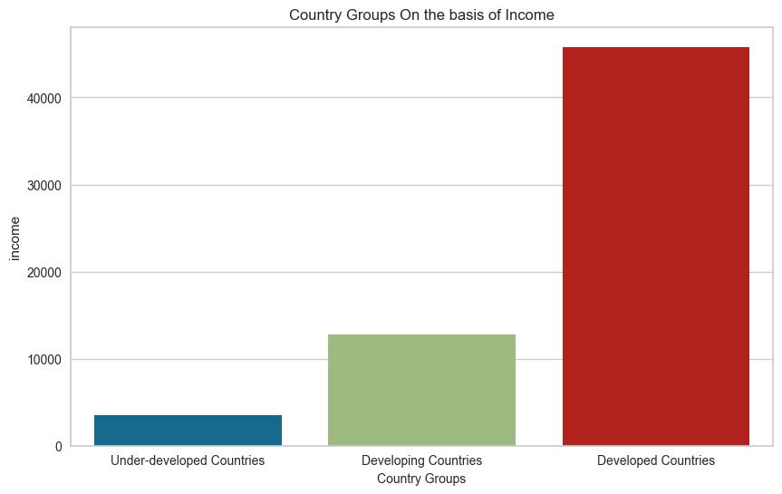

```python
fig = plt.figure(figsize = (10,6))
sns.barplot(x=df.index,y='income',data=df)
plt.xlabel('Country Groups', fontsize=10)
plt.title('Country Groups On the basis of Income')
plt.show()
```

Similarly, Above bar chart shows that, all the developed countries are having high income per person, developing countries are having average income per person and poor countries are having the least income per person.

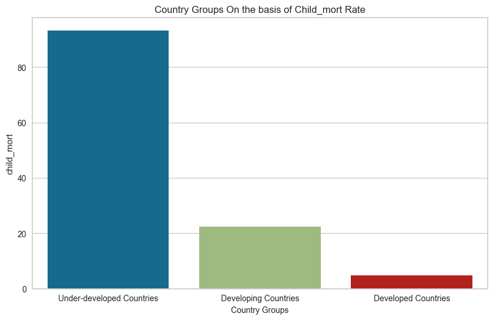

```python
fig = plt.figure(figsize = (10,6))
sns.barplot(x=df.index,y='child_mort',data=df)
plt.xlabel('Country Groups', fontsize=10)
plt.title('Country Groups On the basis of Child_mort Rate')
plt.show()
```

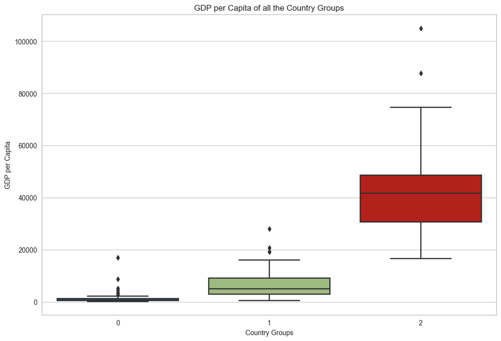

```python
fig = plt.figure(figsize = (12,8))
sns.boxplot(x='cluster',y='gdpp',data=dat6)
plt.xlabel('Country Groups', fontsize=10)
plt.ylabel('GDP per Capita', fontsize=10)
plt.title('GDP per Capita of all the Country Groups')
plt.show()
```

Here, Developed countries are falling under 2nd cluster because of high gdpp range. Poor countries are falling under cluster 0.

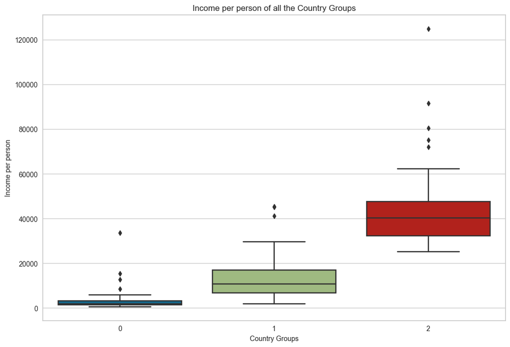

```python
fig = plt.figure(figsize = (12,8))
sns.boxplot(x='cluster',y='income',data=dat6)
plt.xlabel('Country Groups', fontsize=10)
plt.ylabel('Income per person', fontsize=10)
plt.title('Income per person of all the Country Groups')
plt.show()
```

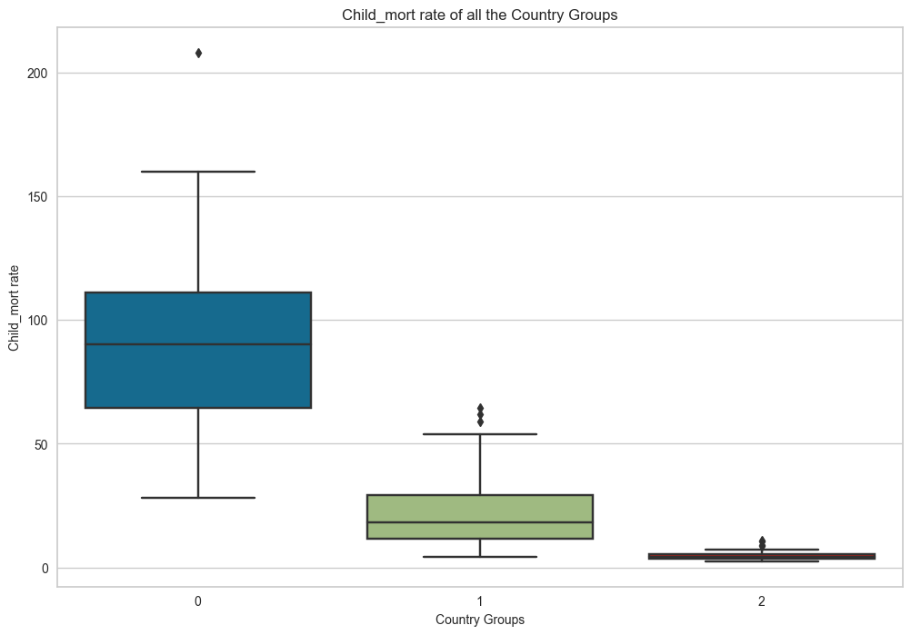

```python
fig = plt.figure(figsize = (12,8))
sns.boxplot(x='cluster',y='child_mort',data=dat6)
plt.xlabel('Country Groups', fontsize=10)
plt.ylabel('Child_mort rate', fontsize=10)
plt.title('Child_mort rate of all the Country Groups')
plt.show()
```

From the above plots we can see poor countries are falling under cluster 0. So, the child_mort rate is more in these countries.

```python
Developed_con_K=dat6[dat6['cluster']==2]
Avg_Developed_con_K=dat6[dat6['cluster']==1]
Poor_con_K=dat6[dat6['cluster']==0]
```

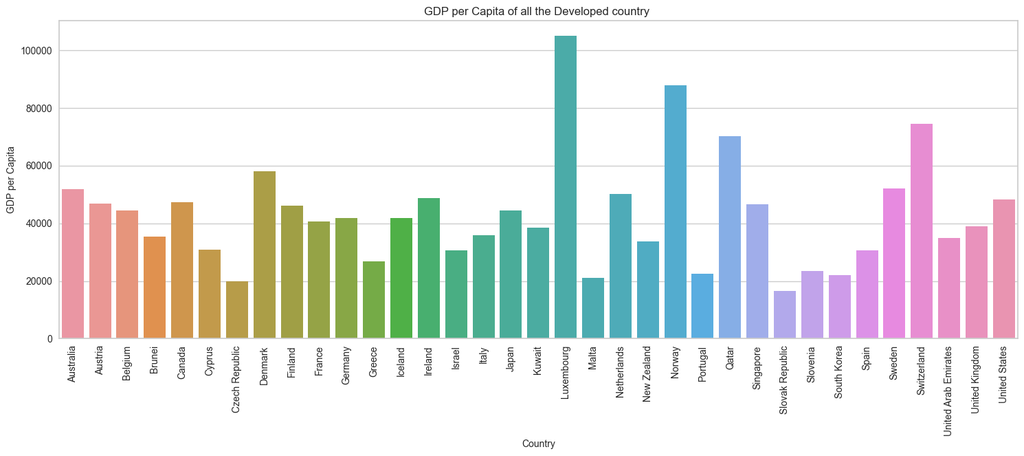

```python
fig = plt.figure(figsize = (18,6))
s=sns.barplot(x='country',y='gdpp',data=Developed_con_K)
s.set_xticklabels(s.get_xticklabels(),rotation=90)
plt.xlabel('Country', fontsize=10)
plt.ylabel('GDP per Capita', fontsize=10)
plt.title('GDP per Capita of all the Developed country ')
plt.show()
```

From the above barchart, we can see all the developed countries like Luxembourg, Australia, etc.

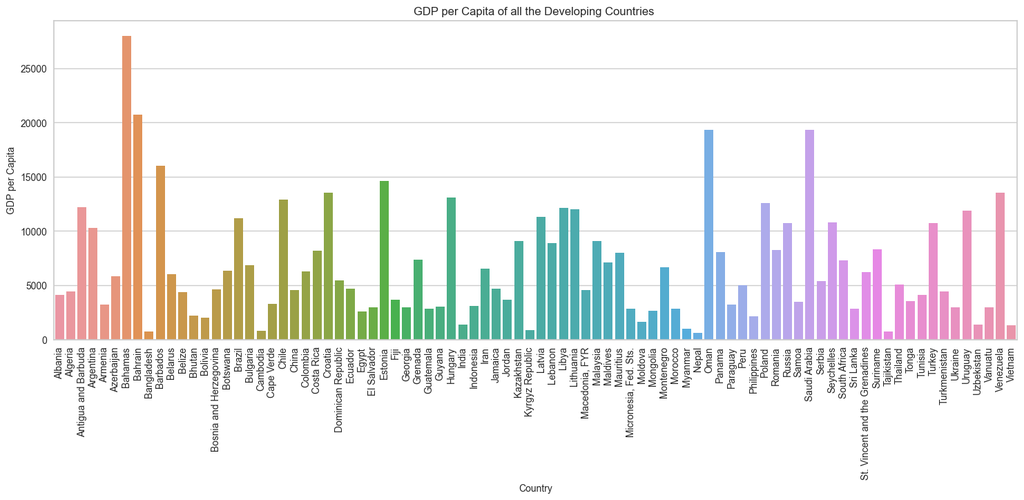

```python
fig = plt.figure(figsize = (18,6))
s=sns.barplot(x='country',y='gdpp',data=Avg_Developed_con_K)
s.set_xticklabels(s.get_xticklabels(),rotation=90)
plt.xlabel('Country', fontsize=10)
plt.ylabel('GDP per Capita', fontsize=10)
plt.title('GDP per Capita of all the Developing Countries ')
plt.show()
```

From the above barchart, we can see all the Developing countries like Iran, Albania, etc.

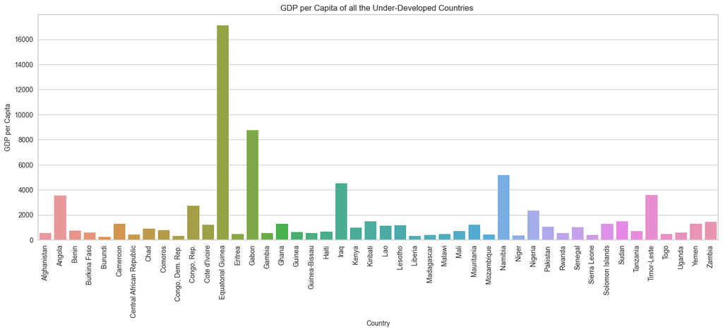

```python
fig = plt.figure(figsize = (18,6))
s=sns.barplot(x='country',y='gdpp',data=Poor_con_K)
s.set_xticklabels(s.get_xticklabels(),rotation=90)
plt.xlabel('Country', fontsize=10)
plt.ylabel('GDP per Capita', fontsize=10)
plt.title('GDP per Capita of all the Under-Developed Countries ')
plt.show()
```

From the above barchart, we can see all the Under-developed countries like Haiti, Sierra Leone, etc., where child_mort rate is more

[figure not shown]

```python
fig = plt.figure(figsize = (18,6))
s=sns.barplot(x='country',y='child_mort',data=Developed_con_K)
s.set_xticklabels(s.get_xticklabels(),rotation=90)
plt.xlabel('Country', fontsize=10)
plt.ylabel('GDP per Capita', fontsize=10)
plt.title('GDP per Capita of all the Developed country ')
plt.show()
```

[figure not shown]

```python
fig = plt.figure(figsize = (18,6))
s=sns.barplot(x='country',y='child_mort',data=Avg_Developed_con_K)
s.set_xticklabels(s.get_xticklabels(),rotation=90)
plt.xlabel('Country', fontsize=10)
plt.ylabel('GDP per Capita', fontsize=10)
plt.title('GDP per Capita of all the Developing Countries ')
plt.show()
```

From the above barchart, we can see all the Avg-developed countries like india,turkmenistan,myanmar etc., where child_mort rate is more

[figure not shown]

```python
fig = plt.figure(figsize = (18,6))
s=sns.barplot(x='country',y='child_mort',data=Poor_con_K)
s.set_xticklabels(s.get_xticklabels(),rotation=90)
plt.xlabel('Country', fontsize=10)
plt.ylabel('GDP per Capita', fontsize=10)
plt.title('GDP per Capita of all the Under-Developed Countries ')
plt.show()
```

From the above barchart, we can see all the Under-developed countries like haiti, Sierra Leone, etc., where child_mort rate is more

[figure not shown]

```python
fig = plt.figure(figsize = (18,6))
s=sns.barplot(x='country',y='income',data=Developed_con_K)
s.set_xticklabels(s.get_xticklabels(),rotation=90)
plt.xlabel('Country', fontsize=10)
plt.ylabel('GDP per Capita', fontsize=10)
plt.title('GDP per Capita of all the Developed country ')
plt.show()
```

From the above barchart, we can see all the developed countries like Qatar, luxembourg, etc., where income rate is more

[figure not shown]

```python
fig = plt.figure(figsize = (18,6))
s=sns.barplot(x='country',y='income',data=Avg_Developed_con_K)
s.set_xticklabels(s.get_xticklabels(),rotation=90)
plt.xlabel('Country', fontsize=10)
plt.ylabel('GDP per Capita', fontsize=10)
plt.title('GDP per Capita of all the Developing Countries ')
plt.show()
```

From the above barchart, we can see all the avg-developed countries like oman, Sierra saudia arabia, etc., where income rate is more

[figure not shown]

```python
fig = plt.figure(figsize = (18,6))
s=sns.barplot(x='country',y='income',data=Poor_con_K)
s.set_xticklabels(s.get_xticklabels(),rotation=90)
plt.xlabel('Country', fontsize=10)
plt.ylabel('GDP per Capita', fontsize=10)
plt.title('GDP per Capita of all the Under-Developed Countries ')
plt.show()
```

# conclusion

After grouping all the countries into 3 groups by using some socio-economic and health factors, we can determine the overall development of the country.

Here, the countries are categorised into list of developed countries, developeing countries and under-developed countries.

In Developed countries, we can see the GDP per capita and income is high where as Death of children under 5 years of age per 1000 live births i.e. child-mort is very low, which is expected.

In Developing countries and Under-developed countries, the GDP per capita and income are low and child-mort is high. Specifically, for under-developed countries, the death rate of children is very high.

# Recomendetions¶ From bar chats, we can clearly see the socio-economic and heath situation of the under developed countries. In countries like Haiti, Sierra Leone,Chad, etc., the death rate of children under 5 years of age per 1000 (child-mort) is high. In countries like Burundi, Congo, Niger, etc., GDP per capita is very low. So, in those countries, the income per person is also low. So, these countries are considered as poor contries. Finally, as per categories of the countries, top 8 under-developed countries which are in direst need of aid are as below: Burundi Congo, Dem. Rep. Niger Sierra Leone Haiti Chad Central African Republic Mozambique